# Análisis de secuenciacion de práctica (Phyloseq)

# Librerias y datos

```r
library(phyloseq)
```

### Abundancia de ASVs

```r
rando <- function(n = 5000) {
  a <- do.call(paste0, replicate(5, sample(LETTERS, n, TRUE), FALSE))
  paste0(a, sprintf("%04d", sample(9999, n, TRUE)), sample(LETTERS, n, TRUE))
}

dim(seqtab.nochim)
seqnames <- rando(636)

# Guardar las secuencias en otro objeto antes de borrarlas

Secuencias <- colnames(seqtab.nochim)
write.csv(Secuencias, "~/CursoR/CursoRgit/Agronomia/Materiales/Secuencias.csv")

# Cambiando nombre con codigo
colnames(seqtab.nochim) <- seqnames

### o nombrarlas de manera ordinal
colnames(seqtab.nochim) <- c(paste0("Seq_",as.character(1:1706)))

# Guardar la tabla
write.csv(seqtab.nochim, "~/CursoR/CursoRgit/Agronomia/Materiales/Tabla_ASVs.csv")
```

### Tabla de asignacion taxonomica

Ahora si todo listo para armar nuestro objeto y usarlo para todo tipo de analisis:

```r
suelo_ch <- phyloseq(otu_table(seqtab.nochim,
                               taxa_are_rows = FALSE),
                     sample_data(metadatos),
                     tax_table(taxa))
```

[output not shown]

# HERRAMIENTAS DE PHYLOSEQ

```r
dim(seqtab.nochim) # 636
```

```
[1]   6 636
```

# Introduccion

Como vimos antes de irnos phyloseq nos ayuda a integrar todos nuestros datos en un objeto para poder analizarlo. La clase de hoy vamos a ver como phyloseq nos deja modificar estos objetos para visualizarlos mejor y seguir con los diferentes tipo de analisis usando los datos de vid.

```r
load("Bio.RData") # siempre se empieza con el objeto de phyloseq
```

# Las primeras visualizaciones de nuestros datos

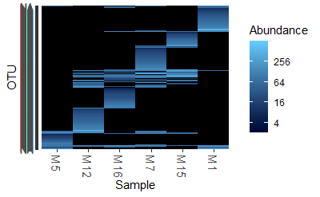

```r
plot_heatmap(Bio, taxa.label = "Phylum")
```

Si bien con estos datos ya podemos realizar grafico que nos acercan mas al analisis el hecho es de que siempre es comvenenientre pre-procesar los datos antes de cualquier grafico. Para ello phyloseq nos ofrece varias herramientas:

# Preproccesamiento de datos

# Union o merge

```r
# Por jerarquia
PS_glom <- tax_glom(PS_filtered, # objeto
                     taxrank = "Genus", # nivel de la jerarquia
                     NArm=FALSE) # que no me quite los valores falsos
# Por jerarquia
PS_glom <- tax_glom(PS_filtered, # objeto
                     taxrank = "Genus", # nivel de la jerarquia
                     NArm=FALSE) # que no me quite los valores falsos
# uniendo phyloseqs
merge_phyloseq(Actino)
```

```
phyloseq-class experiment-level object
otu_table()   OTU Table:         [ 123 taxa and 6 samples ]
sample_data() Sample Data:       [ 6 samples by 2 sample variables ]
tax_table()   Taxonomy Table:    [ 123 taxa by 7 taxonomic ranks ]
```

### Ejercicio unir las muestras de todos

```r
load("phylo_soil.RData")
```

## Abundancia relativa

DADA2 nos da abundancias absolutas las cuales pasamos a nuestro objeto de phyloseq. La abundancia abdoluta es el conteo TOTAL de las especies e individuos dentro de cada especie

La abundancia relativa en cambio normaliza nuestras muestras para poder compararlas entre si. Para ello usa proporciones siendo 1 el 100% de nuestro conteo por muestras. De esta manera podemos comparar la composicion de nuestras muestras aunque no tengamos valores totales o absolutos iguales.

Para transformar de abundancia absoluta a relativa o cualquier otro tipo de calculo para nuestras muestras se usa la siguiente funcion en phyloseq:

```r
Psoil_rel <- transform_sample_counts(PS_filtered, # objeto a transformar
                                     function(x) x/sum(x)) # x es mi conteo
```

# Reexploramos graficos

```r
# 1. Graficos
Top_phyla <- tax_glom(Psoil_rel,taxrank = "Phylum", NArm = FALSE)
Top_phyla <- prune_taxa(names(sort(taxa_sums(Top_phyla), TRUE)[1:10]), #cond
                        Top_phyla) # objeto que voy a modificar

plot_bar(Top_phyla, fill = "Phylum")
plot_heatmap(Top_phyla, taxa.label = "Phylum")
```

[output not shown]